# introduccion

## Python se conoce por ser un lenguaje de programación muy flexible con capacidad para todo.

## Esto se debe en gran parte por sus librerías basadas en el lenguaje que facilitan ciertas funciones del lenguaje.

## En este proyecto utilizaré las siguientes librerías:

```python
import numpy as np
import pandas as pd
import matplotlib.pyplot as plt
import seaborn as sns

from datetime import datetime

import warnings
warnings.filterwarnings('ignore')

from pathlib import Path
data_path = Path("../src")
dataset = Path(data_path / "ElectricityProduction.csv")
data = pd.read_csv(dataset)
```

## 1) Numpy.

[figure not shown]

### Se trata de una librería que proporciona soporte para crear vectores y matrices multidimensionales, además de una gran colección de funciones matemáticas de alto nivel para su operación.

[figure not shown]

### Teniendo en cuenta que una matriz podemos llenarla de varios tipos de datos (enteros,carácteres,irracionales...), esta libreria nos permite todo tipo de operaciones matemáticas entre conjuntos de datos.

### Podemos ver operaciones sencillas:

```python
a = np.array([1,2,3,4,5])
b = np.array([4,5,6,7,8])
print(a+b)
print(a/b)
```

```
[ 5  7  9 11 13]
[0.25       0.4        0.5        0.57142857 0.625     ]
```

### Otras operaciones con carácteres:

```python
c = np.array([' este es un ejemplo para el proyecto de fin de grado'])
c1 = np.char.strip(c)
c2 = np.char.split(c1, sep=' ')
c2 = np.array(c2[0])
c3 = np.char.capitalize(c2)
np.char.startswith(c3,prefix='E')
```

```
array([ True,  True, False,  True, False,  True, False, False, False,
       False, False])
```

### Incluso operaciones estadísticas:

```python
array = np.array([44, 28,  8, 34, 34, 26, 32, 12, 28,  6, 19, 12, 46, 20, 20, 49, 18,
       19, 15, 15, 43,  3, 17, 33, 27, 10, 18,  2,  3,  3, 35, 35, 21, 17,
       36, 31, 16, 27,  6, 46, 29, 25, 26, 48, 30, 19, 18,  1, 43, 10, 32,
       15, 32, 30, 40, 41, 11, 46, 39,  5, 40,  1, 26, 10, 18, 26, 25, 25,
       21, 30, 12, 46,  1, 43,  1,  3, 26, 24,  0, 36, 34,  7, 26, 25, 41,
       22,  1, 16, 43,  1, 46, 14, 17, 39, 12,  9, 42, 48,  9, 45, 47, 32,
       15,  6, 40, 18,  6, 13, 35,  8, 46, 48, 26, 23, 12, 29, 21,  6,  3,
       22, 27, 16, 27, 10, 28, 23,  5, 24, 17, 43, 25, 11, 38, 40, 32, 42,
       27, 32,  6, 16, 18, 10, 18, 34, 34,  3,  4,  5,  4,  0, 35, 30,  9,
       16, 32, 46,  7, 10, 20, 13, 48,  8, 27, 27, 27, 16, 17, 12, 35, 31,
       21, 29, 15, 49, 14, 22, 18,  0, 13, 14, 39, 30,  4, 48,  1, 19, 33,
       39,  9,  0, 24,  6, 12, 24, 29, 16, 11, 12, 13, 11])
media = np.mean(array)
mediana = np.median(array)
tercer_q = np.quantile(array, q=0.75)
perc_50 = np.percentile(array, q=50)
des = np.std(array)
var = np.var(array)
print(["Media:",media],["Mediana:",mediana],["Tercer Cuartil:",tercer_q])
print(["Percentil 50:",perc_50],["Desviación Típica:",des],["Varianza:",var])
```

```
['Media:', 22.405] ['Mediana:', 21.0] ['Tercer Cuartil:', 32.0]
['Percentil 50:', 21.0] ['Desviación Típica:', 13.66934435150421] ['Varianza:', 186.85097500000003]
```

## 2) Pandas.

[figure not shown]

### Pandas es una librería que facilita la manipulación y análisis de datos mediante la proporción de tablas númericas y series temporales.

[figure not shown]

### Como ejemplo, voy a utilizar un conjunto de datos sobre la producción de electricidad a nivel mundial.

### Para ver un poco del dataset, podemos ver los primeros registros:

```python
data.head()
```

|  | country_name | date | parameter | product | value | unit |
| --- | --- | --- | --- | --- | --- | --- |
| 0 | Australia | 12/1/2023 | Net Electricity Production | Electricity | 22646.1901 | GWh |
| 1 | Australia | 12/1/2023 | Net Electricity Production | Total Combustible Fuels | 13397.9356 | GWh |
| 2 | Australia | 12/1/2023 | Net Electricity Production | Coal, Peat and Manufactured Gases | 9768.5223 | GWh |
| 3 | Australia | 12/1/2023 | Net Electricity Production | Oil and Petroleum Products | 289.5415 | GWh |
| 4 | Australia | 12/1/2023 | Net Electricity Production | Natural Gas | 3091.9272 | GWh |

### Vemos que el dataset tiene 6 campos. Con este pequeño vistazo podemos ir viendo que campos nos interesará estudiar.

### Una de las funciones más útil es la consulta, que nos permite filtrar datos a nuestro interés.

### Por ejemplo, voy a filtar por la producción de electricidad en España durante un día concreto.

```python
data.query('date == "12/1/2023" & country_name == "Spain"')
```

|  | country_name | date | parameter | product | value | unit |
| --- | --- | --- | --- | --- | --- | --- |
| 492 | Spain | 12/1/2023 | Net Electricity Production | Electricity | 22924.6780 | GWh |
| 493 | Spain | 12/1/2023 | Net Electricity Production | Nuclear | 4990.1643 | GWh |
| 494 | Spain | 12/1/2023 | Net Electricity Production | Total Combustible Fuels | 5660.5453 | GWh |
| 495 | Spain | 12/1/2023 | Net Electricity Production | Coal, Peat and Manufactured Gases | 245.5875 | GWh |
| 496 | Spain | 12/1/2023 | Net Electricity Production | Oil and Petroleum Products | 805.6821 | GWh |
| 497 | Spain | 12/1/2023 | Net Electricity Production | Natural Gas | 4171.0379 | GWh |
| 498 | Spain | 12/1/2023 | Net Electricity Production | Combustible Renewables | 392.9387 | GWh |
| 499 | Spain | 12/1/2023 | Net Electricity Production | Other Combustible Non-Renewables | 45.2991 | GWh |
| 500 | Spain | 12/1/2023 | Net Electricity Production | Hydro | 4425.7396 | GWh |
| 501 | Spain | 12/1/2023 | Net Electricity Production | Wind | 5817.5004 | GWh |
| 502 | Spain | 12/1/2023 | Net Electricity Production | Solar | 2007.8118 | GWh |
| 503 | Spain | 12/1/2023 | Net Electricity Production | Other Renewables | 1.5000 | GWh |
| 504 | Spain | 12/1/2023 | Net Electricity Production | Not Specified | 21.4167 | GWh |
| 505 | Spain | 12/1/2023 | Net Electricity Production | Total Renewables (Hydro, Geo, Solar, Wind, Other) | 12645.4906 | GWh |
| 506 | Spain | 12/1/2023 | Total Imports | Electricity | 1399.9889 | GWh |
| 507 | Spain | 12/1/2023 | Total Exports | Electricity | 2175.3525 | GWh |
| 508 | Spain | 12/1/2023 | Used for pumped storage | Electricity | 683.8258 | GWh |
| 509 | Spain | 12/1/2023 | Distribution Losses | Electricity | 2203.3597 | GWh |
| 510 | Spain | 12/1/2023 | Final Consumption (Calculated) | Electricity | 19262.1290 | GWh |

## 3) Matplotlib.

[figure not shown]

### Librería que genera gráficos de dos dimensiones a partir de conjuntos de datos contenidos en listas o arrays de Python.

[figure not shown]

### Matplotlib nos permite todo tipo de gráficos.

### Desde gráficos más simples:

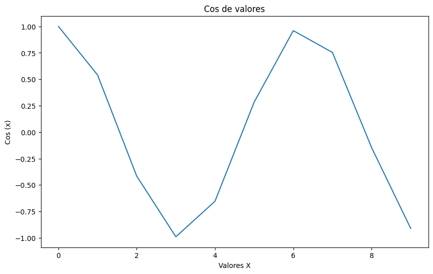

```python
fig, ax = plt.subplots(figsize = (10,6))

x = np.arange(10)
y = np.cos(x)

ax.plot(x,y)
#Para modificar la grafica.
ax.set(xlabel='Valores X', ylabel='Cos (x)', title='Cos de valores');
```

```python
gen = data.query('country_name == "Spain" & parameter == "Final Consumption (Calculated)" & date in ["12/1/2023","11/1/2023","10/1/2023","9/1/2023","8/1/2023"]')
gen
```

|  | country_name | date | parameter | product | value | unit |
| --- | --- | --- | --- | --- | --- | --- |
| 510 | Spain | 12/1/2023 | Final Consumption (Calculated) | Electricity | 19262.1290 | GWh |
| 1221 | Spain | 11/1/2023 | Final Consumption (Calculated) | Electricity | 18184.7881 | GWh |
| 1933 | Spain | 10/1/2023 | Final Consumption (Calculated) | Electricity | 18171.5690 | GWh |
| 2647 | Spain | 9/1/2023 | Final Consumption (Calculated) | Electricity | 18104.9334 | GWh |
| 3362 | Spain | 8/1/2023 | Final Consumption (Calculated) | Electricity | 20000.9111 | GWh |

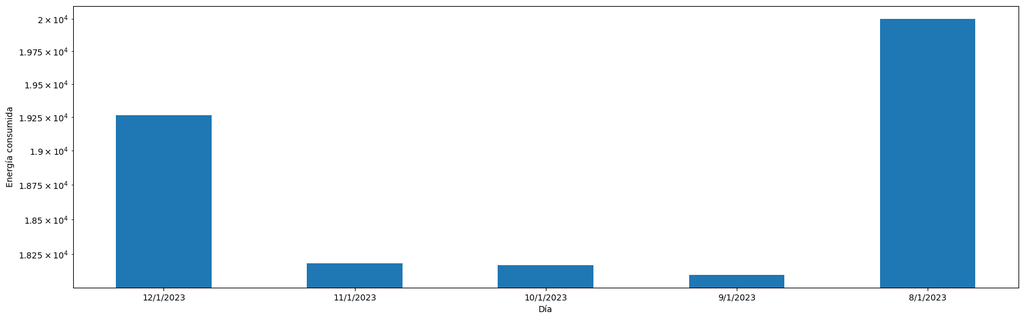

```python
fig, ax = plt.subplots(figsize = (20,6))

ax.bar(x=gen["date"], height=gen["value"], width=0.5, align='center')
#Cogemos como eje x el indice, como altura los valores, le damos un ancho y que estén en medio.
#Podemos modificar la escala del eje y:
ax.set_yscale('log')
#Añadimos etiquetas:
ax.set_xlabel('Día')
ax.set_ylabel('Energía consumida')
#Modificamos los valores del eje X con:
ax.set_xticks(gen["date"]);
```

### hasta gráficos más complejos:

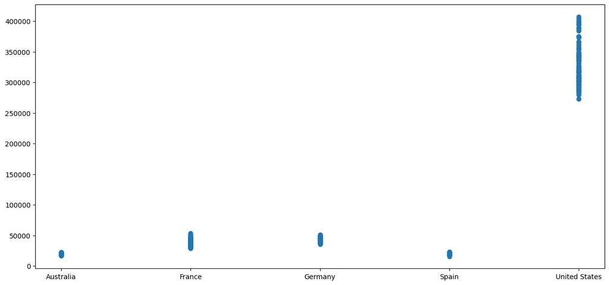

```python
fig , ax = plt.subplots(figsize = (15,7))
g1 = data.query('country_name in ["Spain","Germany","Australia","United States","France"] & parameter == "Final Consumption (Calculated)"')
x = g1['country_name']
y = g1['value']

#Podemos modificar el color añadiendolo en C.
color = ['','green','yellow','blue','gray','red']

#Creamos una variable para modificar el tamaño del punto, y la añadimos en s.


ax.scatter(x=x,y=y);
```

## 4) Seaborn.

[figure not shown]

### Librería que permite crear gráficos estádisticos en Python a partir de conjuntos de datos.

[figure not shown]

### Estos gráficos son más avanzados y suelen utilizarse para crear predicciones basadas en la estadística.

### Entre ellos se encuentra el gráfico de regresión

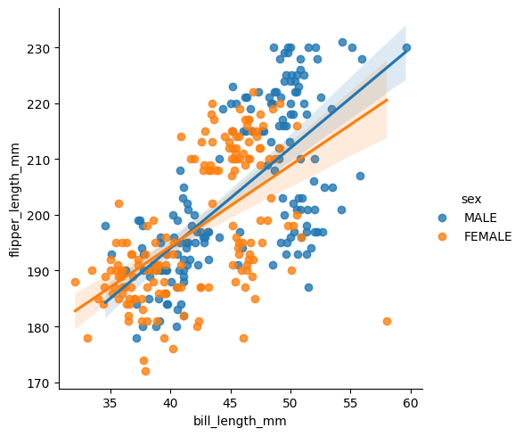

```python
sns.lmplot(x='bill_length_mm', y='flipper_length_mm', data=datagit, hue='sex');
```

### O gráficos de cajas, que sirven para detectar valores anómalos

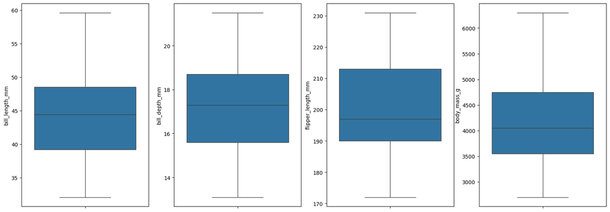

```python
cols = ['bill_length_mm', 'bill_depth_mm','flipper_length_mm', 'body_mass_g']
i = 0
fig, ax = plt.subplots(ncols=4, figsize=(20,7))
for c in cols:
    sns.boxplot(datagit[c], ax=ax[i])
    i+=1
```

### Incluso un gráfico que contenga todas las combinaciones de variables

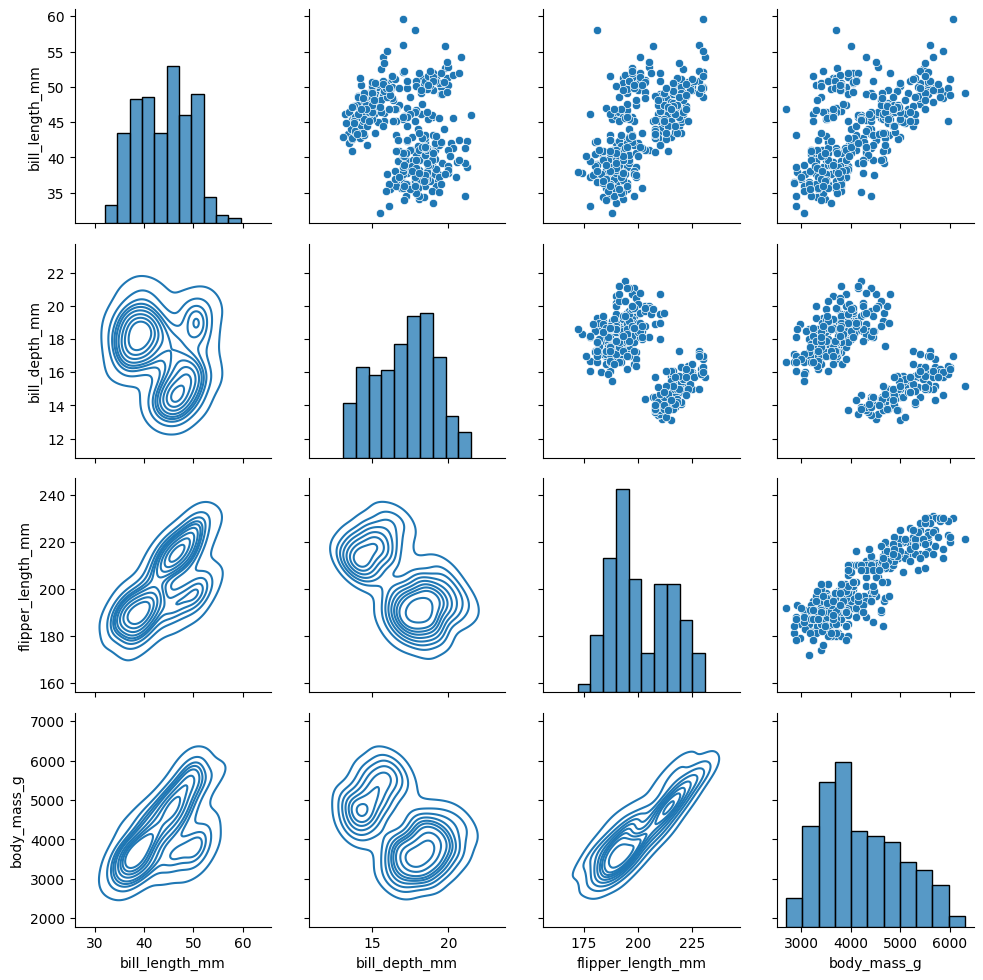

```python
g = sns.PairGrid(data=datagit)
g.map_diag(sns.histplot)
g.map_upper(sns.scatterplot)
g.map_lower(sns.kdeplot)
```